# Tarea02. Métodos kernel para regresión

## David Montero Loaiza

Para esta tarea crearás un script que predice la serie temporal del CO2 atmosférico con datos actualizados del repositorio de la National Oceanic and Atmospheric Administration https://www.esrl.noaa.gov/gmd/ccgg/trends/data.html.

```python
import numpy as np
import pandas as pd
import matplotlib.pyplot as plt
from sklearn import datasets, svm

# inline plots
%matplotlib inline
```

### Escribe una función que descargue automáticamente el fichero de datos con medidas mensuales de la URL ftp://aftp.cmdl.noaa.gov/products/trends/co2/co2_mm_mlo.txt y que lo convierta a un formato numérico (dataframe, numpy arrays, etc.).

```python
data = pd.DataFrame(np.loadtxt("ftp://aftp.cmdl.noaa.gov/products/trends/co2/co2_mm_mlo.txt"))
```

### Obten las variables months y avg_ppmvs.

```python
data.columns = ['year','month','months','avg','avg_ppmvs','trend','days']
data = data[['months','avg_ppmvs']]
```

### Comprueba si los datos coinciden con los datos usados en la práctica (devueltos por load_mauna_loa_atmospheric_co2()) para las fechas en que existen datos en ambos conjuntos.

```python
from sklearn.datasets import fetch_openml

def load_mauna_loa_atmospheric_co2():
    ml_data = fetch_openml(data_id=41187, cache=False)
    months = []
    ppmv_sums = []
    counts = []

    y = ml_data.data[:, 0]
    m = ml_data.data[:, 1]
    month_float = y + (m - 1) / 12
    ppmvs = ml_data.target

    for month, ppmv in zip(month_float, ppmvs):
        if not months or month != months[-1]:
            months.append(month)
            ppmv_sums.append(ppmv)
            counts.append(1)
        else:
            # aggregate monthly sum to produce average
            ppmv_sums[-1] += ppmv
            counts[-1] += 1

    months = np.asarray(months).reshape(-1, 1)
    avg_ppmvs = np.asarray(ppmv_sums) / counts
    return months, avg_ppmvs

X, y = load_mauna_loa_atmospheric_co2()
```

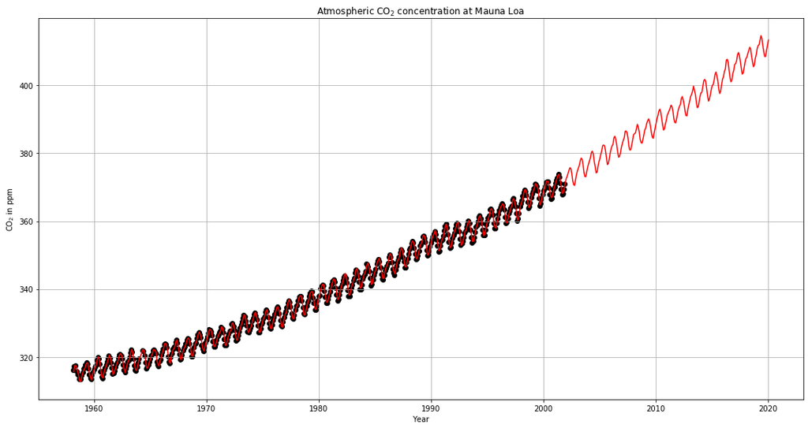

```python
fig = plt.figure(figsize=(15,8))
plt.scatter(X, y, c='black')
plt.plot(data.months,data.avg_ppmvs, c='red')
plt.grid(True)
plt.xlabel("Year")
plt.ylabel(r"CO$_2$ in ppm")
plt.title(r"Atmospheric CO$_2$ concentration at Mauna Loa")
plt.tight_layout()
plt.show()
```

Si bien los datos de la práctica no coinciden exactamente en sus valores con los descargados de la NOAA, mantienen una desviación muy baja en torno a los valores obtenidos directamente de la NOAA.

### Busca los mejores hiperparámetros del GP para predecir la serie temporal del CO2 usando datos hasta la fecha más reciente. Compara estos hiperparámetros con los que se encontraron al usar datos hasta diciembre de 2001 (los datos usados en la práctica).

```python
from sklearn.gaussian_process import GaussianProcessRegressor
from sklearn.gaussian_process.kernels import RBF, ConstantKernel as C, WhiteKernel
from sklearn.gaussian_process.kernels import RationalQuadratic
from sklearn.gaussian_process.kernels import ExpSineSquared

from time import time

X = np.array(data.months).reshape(-1,1)
y = data.avg_ppmvs

k1 = C(50, (1e1, 1e+3)) * RBF(50,(1e0,1e5))  # long term smooth rising trend
k2 = C(5, (1e1, 1e+2)) * RBF(100,(1e0,1e5)) \
    * ExpSineSquared(length_scale=1.0, length_scale_bounds=(1e-1,1e1),
                     periodicity=1.0, periodicity_bounds="fixed")  # seasonal component
k3 = C(0.5, (1e-2, 1e1)) * RationalQuadratic(length_scale=1.0, length_scale_bounds=(1e-2,1e3),
                                alpha=1.0, alpha_bounds=(1e-1,1e3)) # medium term irregularities
k4 = C(0.1, (1e-3, 1e+1)) * RBF(0.1,(1e-2,1e2)) \
    + WhiteKernel(noise_level=0.1**2,noise_level_bounds=(1e-4, 1e0)) # noise terms

kernel = k1 + k2 + k3 + k4

gp = GaussianProcessRegressor(kernel=kernel, alpha=0,normalize_y=True, n_restarts_optimizer=1)

t0 = time()

gp.fit(X,y)

print("Elapsed time: %0.3fs"%(time() - t0))

print("\nLearned kernel: %s" % gp.kernel_)
print("Log-marginal-likelihood: %.3f" % gp.log_marginal_likelihood(gp.kernel_.theta))

X_ = np.linspace(X.min(), X.max() + 20, 1000)[:,np.newaxis]
y_pred, y_std = gp.predict(X_, return_std=True)
```

```
Elapsed time: 48.350s

Learned kernel: 31.6**2 * RBF(length_scale=28) + 3.16**2 * RBF(length_scale=164) * ExpSineSquared(length_scale=1.49, periodicity=1) + 0.733**2 * RationalQuadratic(alpha=0.285, length_scale=1.25) + 0.187**2 * RBF(length_scale=0.117) + WhiteKernel(noise_level=0.0406)
Log-marginal-likelihood: -187.348
```

Hiperparámetros hasta diciembre de 2001 (LML = -115.438):

```
    31.6**2 * RBF(length_scale=45.6)
    + 3.16**2 * RBF(length_scale=97.1) * ExpSineSquared(length_scale=1.58, periodicity=1)
    + 0.536**2 * RationalQuadratic(alpha=3.05, length_scale=0.967)
    + 0.189**2 * RBF(length_scale=0.122) + WhiteKernel(noise_level=0.0367)
```

Hiperparámetros con todos los datos (LML = -187.348):

```
    31.6**2 * RBF(length_scale=28)
    + 3.16**2 * RBF(length_scale=164) * ExpSineSquared(length_scale=1.49, periodicity=1)
    + 0.733**2 * RationalQuadratic(alpha=0.285, length_scale=1.25)
    + 0.187**2 * RBF(length_scale=0.117) + WhiteKernel(noise_level=0.0406)
```

### Haz una figura que muestre la serie temporal completa y una predicción de los próximos 20 años, incluso bandas de confianza.

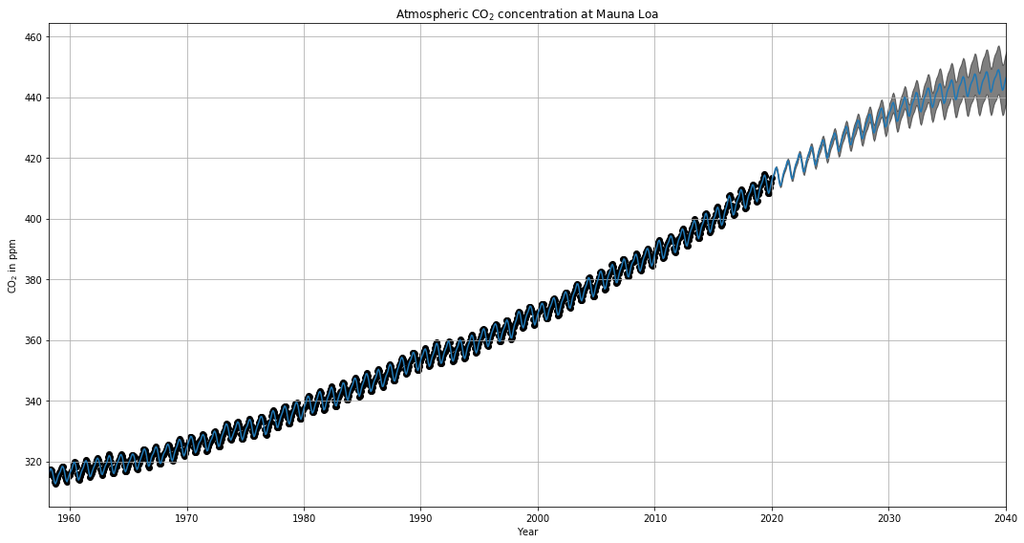

```python
fig = plt.figure(figsize=(15,8))
plt.scatter(X, y, c='k')
plt.plot(X_, y_pred)
plt.fill_between(X_[:, 0], y_pred - y_std, y_pred + y_std,alpha=0.5, color='k')
plt.xlim(X_.min(), X_.max())
plt.grid(True)
plt.xlabel("Year")
plt.ylabel(r"CO$_2$ in ppm")
plt.title(r"Atmospheric CO$_2$ concentration at Mauna Loa")
plt.tight_layout()
plt.show()
```

Puede observarse en la gráfica, como el modelo mantiene un buen nivel de confianza incluso hasta el año 2030, no obstante, para los siguientes 10 años, ese nivel de confianza disminuye lo suficiente como para descartar el modelo como predivtivo para más de 10 años.

Pon a tu notebook el nombre de fichero "T02_apellido1_apellido2_nombre.ipynb" y entrégalo en formato zip.